# OncoSimulR: forward genetic simulation in asexual populations with arbitrary epistatic interactions and a focus on modeling tumor progression.

Ramon Diaz-Uriarte, Sergio Sanchez-Carrillo, Juan Antonio Miguel-Gonzalez Dept. Biochemistry, Universidad Autónoma de Madrid, Instituto de Investigaciones Biomédicas ‘Alberto Sols’ (UAM-CSIC), Madrid, Spain. ramon.diaz@iib.uam.es, https://ligarto.org/rdiaz

2021-01-26. OncoSimulR version 2.99.7

# 1 Introduction

OncoSimulR is an individual- or clone-based forward-time genetic simulator for biallelic markers (wildtype vs. mutated) in asexually reproducing populations without spatial structure (perfect mixing). Its design emphasizes flexible specification of fitness and mutator effects.

OncoSimulR was originally developed to simulate tumor progression with emphasis on allowing users to set restrictions in the accumulation of mutations as specified, for example, by Oncogenetic Trees (OT: Desper et al. 1999; Szabo and Boucher 2008) or Conjunctive Bayesian Networks (CBN: Beerenwinkel, Eriksson, and Sturmfels 2007; Gerstung et al. 2009, 2011), with the possibility of adding passenger mutations to the simulations and allowing for several types of sampling.

Since then, OncoSimulR has been vastly extended to allow you to specify other types of restrictions in the accumulation of genes, such as the XOR models of Korsunsky et al. (2014) or the “semimonotone” model of Farahani and Lagergren (2013). Moreover, different fitness effects related to the order in which mutations appear can also be incorporated, involving arbitrary numbers of genes. This is *very* different from “restrictions in the order of accumulation of mutations”. With order effects, described in a recent cancer paper by Ortmann and collaborators (Ortmann et al. 2015), the effect of having both mutations “A” and “B” differs depending on whether “A” appeared before or after “B” (the actual case involves genes JAK2 and TET2).

More generally, OncoSimulR now also allows you to specify arbitrary epistatic interactions between arbitrary collections of genes and to model, for example, synthetic mortality or synthetic viability (again, involving an arbitrary number of genes, some of which might also depend on other genes, or show order effects with other genes). Moreover, it is possible to specify the above interactions in terms of modules, not genes. This idea is discussed in, for example, Raphael and Vandin (2015) and Gerstung et al. (2011): the restrictions encoded in, say, CBNs or OT can be considered to apply not to genes, but to modules, where each module is a set of genes (and the intersection between modules is the empty set) that performs a specific biological function. Modules, then, play the role of a “union operation” over the set of genes in a module. In addition, arbitrary numbers of genes without interactions (and with fitness effects coming from any distribution you might want) are also possible.

You can also directly specify the mapping between genotypes and fitness and, thus, you can simulate on fitness landscapes of arbitrary complexity.

It is now (released initially in this repo as the freq-dep-fitness branch on February 2019) also possible to simulate scenarios with frequency-dependent fitness, where the fitness of one or more genotypes depends on the relative or absolute frequencies of other genotypes, as in game theory and adaptive dynamics. This makes it possible to model predation and parasitism, cooperation and mutualism, and commensalism. It also allows to model therapeutic interventions (where fitness changes at specified time points or as a function of the total populations size).

Simulations can start from arbitrary initial population compositions and it is also possible to simulate multiple species. Thus, simulations that involve both ecological and evolutionary processes are possible.

Mutator/antimutator genes, genes that alter the mutation rate of other genes (Gerrish et al. 2007; Tomlinson, Novelli, and Bodmer 1996), can also be simulated with OncoSimulR and specified with most of the mechanisms above (you can have, for instance, interactions between mutator genes). And, regardless of the presence or not of other mutator/antimutator genes, different genes can have different mutation rates.

Simulations can be stopped as a function of total population size, number of mutated driver genes, or number of time periods. Simulations can also be stopped with a stochastic detection mechanism where the probability of detecting a tumor increases with total population size. Simulations return the number of cells of every genotype/clone at each of the sampling periods and we can take samples from the former with single-cell or whole- tumor resolution, adding noise if we want. If we ask for them, simulations also store and return the genealogical relationships of all clones generated during the simulation.

The models so far implemented are all continuous time models, which are simulated using the BNB algorithm of Mather, Hasty, and Tsimring (2012). The core of the code is implemented in C++, providing for fast execution. To help with simulation studies, code to simulate random graphs of the kind often seen in CBNs, OTs, etc, is also available. Finally, OncoSimulR also allows for the generation of random fitness landscapes and the representation of fitness landscapes and provides statistics of evolutionary predictability.

## 1.1 Key features of OncoSimulR

As mentioned above, OncoSimulR is now a very general package for forward genetic simulation, with applicability well beyond tumor progression. This is a summary of some of its key features:

- You can specify arbitrary interactions between genes, with arbitrary fitness effects, with explicit support for:
  - Restrictions in the accumulations of mutations, as specified by Oncogenetic Trees (OTs), Conjunctive Bayesian Networks (CBNs), semimonotone progression networks, and XOR relationships.
  - Epistatic interactions including, but not limited to, synthetic viability and synthetic lethality.
  - Order effects.
- You can add passenger mutations.
- You can add mutator/antimutator effects.
- Fitness and mutation rates can be gene-specific.
- You can add arbitrary numbers of non-interacting genes with arbitrary fitness effects.
- you can allow for deviations from the OT, CBN, semimonotone, and XOR models, specifying a penalty for such deviations (the $s_h$ parameter).
- You can conduct multiple simulations, and sample from them with different temporal schemes and using both whole tumor or single cell sampling.
- You can stop the simulations using a flexible combination of conditions: final time, number of drivers, population size, fixation of certain genotypes, and a stochastic stopping mechanism that depends on population size.
- Right now, three different models are available, two that lead to exponential growth, one of them loosely based on Bozic et al. (2010), and another that leads to logistic-like growth, based on McFarland et al. (2013).
- You can use large numbers of genes (e.g., see an example of 50000 in section 6.5.3).
- Simulations are generally very fast: I use C++ to implement the BNB algorithm (see sections 15.5 and 15.6 for more detailed comments on the usage of this algorithm).
- You can obtain the true sequence of events and the phylogenetic relationships between clones (see section 15.1 for the details of what we mean by “clone”).
- You can generate random fitness landscapes (under the House of Cards, Rough Mount Fuji, or additive models, or combinations of the former and under the NK model) and use those landscapes as input to the simulation functions.
- You can plot fitness landscapes.
- You can obtain statistics of evolutionary predictability from the simulations.
- You can now also use simulations with frequency-dependent fitness: fitness (birth rate) is not fixed for a genotype, but can be a function of the frequecies of the clones (see section 10). We can therefore use OncoSimulR to examine, via simulations, results from game theory and adaptive dynamics and study complex scenarios that are not amenable to analytical solutions. More generally, we can model predation and parasitism, cooperation and mutualism, and commensalism.
- It is possible to start the simulation with arbitrary initial composition (section 6.7) and to simulate multiple species (section 6.8). You can thus run simulations that involve both ecological and evolutionary processes involving inter-species relationships plus genetic restrictions in evolution.
- It is possible to simulate many different therapeutic interventions. Section 12 shows examples of interventions where certain genotypes change fitness (because of chemotherapy) at specified times. More generally, since fitness (birth rates) can be made a function of total populations sizes and/or frequencies (see section 10), many different arbitrary intervention schemes can be simulated. Possible models are, of course, not limited to cancer chemotherapy, but could include antibiotic treatment of bacteria, antiviral therapy, etc.

The table below, modified from the table at the [Genetics Simulation Resources (GSR) page](https://popmodels.cancercontrol.cancer.gov/gsr/packages/oncosimulr/#detailed), provides a summary of the key features of OncoSimulR. (An explanation of the meaning of terms specific to the GSR table is available from https://popmodels.cancercontrol.cancer.gov/gsr/search/ or from the [Genetics Simulation Resources table itself](https://popmodels.cancercontrol.cancer.gov/gsr/packages/oncosimulr/#detailed), by moving the mouse over each term).

Table 1.1: Key features of OncoSimulR. Modified from the original table from https://popmodels.cancercontrol.cancer.gov/gsr/packages/oncosimulr/#detailed .

| Attribute Category | Attribute |
| --- | --- |
| **Target** |  |
| Type of Simulated Data | Haploid DNA Sequence |
| Variations | Biallelic Marker, Genotype or Sequencing Error |
| **Simulation Method** | Forward-time |
| Type of Dynamical Model | Continuous time |
| Entities Tracked | Clones (see 15.2) |
| **Input** | Program specific (R data frames and matrices specifying genotypes’ fitness, gene effects, and starting genotype) |
| **Output** |  |
| Data Type | Genotype or Sequence, Individual Relationship (complete parent-child relationships between clones), Demographic (populations sizes of all clones at sampling times), Diversity Measures (LOD, POM, diver… |
| Sample Type | Random or Independent, Longitudinal, Other (proportional to population size) |
| **Evolutionary Features** |  |
| Mating Scheme | Asexual Reproduction |
| Demographic |  |
| Population Size Changes | Exponential (two models), Logistic (McFarland et al., 2013) |
| Fitness Components |  |
| Birth Rate | Individually Determined from Genotype (models “Exp”, “McFL”, “McFLD”). Frequency-Dependently Determined from Genotype (models “Exp”, “McFL”, “McFLD”) |
| Death Rate | Individually Determined from Genotype (model “Bozic”), Influenced by Environment —population size (models “McFL” and “McFLD”) |
| Natural Selection |  |
| Determinant | Single and Multi-locus, Fitness of Offspring, Environmental Factors (population size, genotype frequencies) |
| Models | Directional Selection, Multi-locus models, Epistasis, Random Fitness Effects, Frequency-Dependent |
| Mutation Models | Two-allele Mutation Model (wildtype, mutant), without back mutation |
| Events Allowed | Varying Genetic Features: change of individual mutation rates (mutator/antimutator genes) |
| Spatial Structure | No Spatial Structure (perfectly mixed and no migration) |

Further details about the original motivation for wanting to simulate data this way in the context of tumor progression can be found in Diaz-Uriarte (2015), where additional comments about model parameters and caveats are discussed.

Are there similar programs? The Java program by Reiter et al. (2013), TTP, offers somewhat similar functionality to the previous version of OncoSimulR, but it is restricted to at most four drivers (whereas v.1 of OncoSimulR allowed for up to 64), you cannot use arbitrary CBNs or OTs (or XORs or semimonotone graphs) to specify restrictions, there is no allowance for passengers, and a single type of model (a discrete time Galton-Watson process) is implemented. The current functionality of OncoSimulR goes well beyond the the previous version (and, thus, also the TPT of Reiter et al. (2013)). We now allow you to specify all types of fitness effects in other general forward genetic simulators such as FFPopSim (Zanini and Neher 2012), and some that, to our knowledge (e.g., order effects) are not available from any genetics simulator. In addition, the “Lego system” to flexibly combine different fitness specifications is also unique; by “Lego system” I mean that we can combine different pieces and blocks, similarly to what we do with Lego bricks. (I find this an intuitive and very graphical analogy, which I have copied from Hothorn et al. (2006) and Hothorn et al. (2008)). In a nutshell, salient features of OncoSimulR compared to other simulators are the unparalleled flexibility to specify fitness and mutator effects, with modules and order effects as particularly unique, and the options for sampling and stopping the simulations, particularly convenient in cancer evolution models. Also unique in this type of software is the addition of functions for simulating fitness landscapes and assessing evolutionary predictability.

## 1.2 What kinds of questions is OncoSimulR suited for?

OncoSimulR can be used to address questions that span from the effect of mutator genes in cancer to the interplay between fitness landscapes and mutation rates. The main types of questions that OncoSimulR can help address involve combinations of:

- Simulating asexual evolution (the `oncoSimul*` functions) where:
  - Fitness is:
    - A function of specific epistatic effects between genes
    - A function of order effects
    - A function of epistatic effects specified using DAGs/posets where these DAGs/posets:
      - Are user-specified
      - Generated randomly (`simOGraph`)
    - Any mapping between genotypes and fitness where this mapping is:
      - User-specified
      - Generated randomly from families of random fitness landscapes (`rfitness`)
    - A function of the frequency of other genotypes (i.e., frequency-dependent fitness), such as in adaptive dynamics (see section 10 for more details). This also allows you to model competition, cooperation and mutualism, parasitism and predation, and commensalism between clones.
  - Mutation rates can:
    - Vary between genes
    - Be affected by other genes
- Examining times to evolutionarily or biomedically relevant events (fixation of genotypes, reaching a minimal size, acquiring a minimal number of driver genes, etc —specified with the stopping conditions to the `oncoSimul*` functions).
- Using different sampling schemes (`samplePop`) that are related to:
  - Assessing genotypes from single-cell vs. whole tumor (or whole population) with the `typeSample` argument
  - Genotyping error (`propError` argument)
  - Timing of samples (`timeSample` argument)
  - … and assessing the consequences of those on the observed genotypes and their diversity (`sampledGenotypes`) and any other inferences that depend on the observational process.
  - (OncoSimulR returns the abundances of all genotypes at each of the sampling points, so you are not restricted by what the `samplePop` function provides.)
- Tracking the genealogical relationships of clones (`plotClonePhylog`) and assessing evolutionary predictability (`LOD`, `POM`).

Some specific questions that you can address with the help of OncoSimulR are discussed in section 1.3.

A quick overview of the main functions and their relationships is shown in Figure 1.1, where we use italics for the type/class of R object and courier font for the name of the functions.

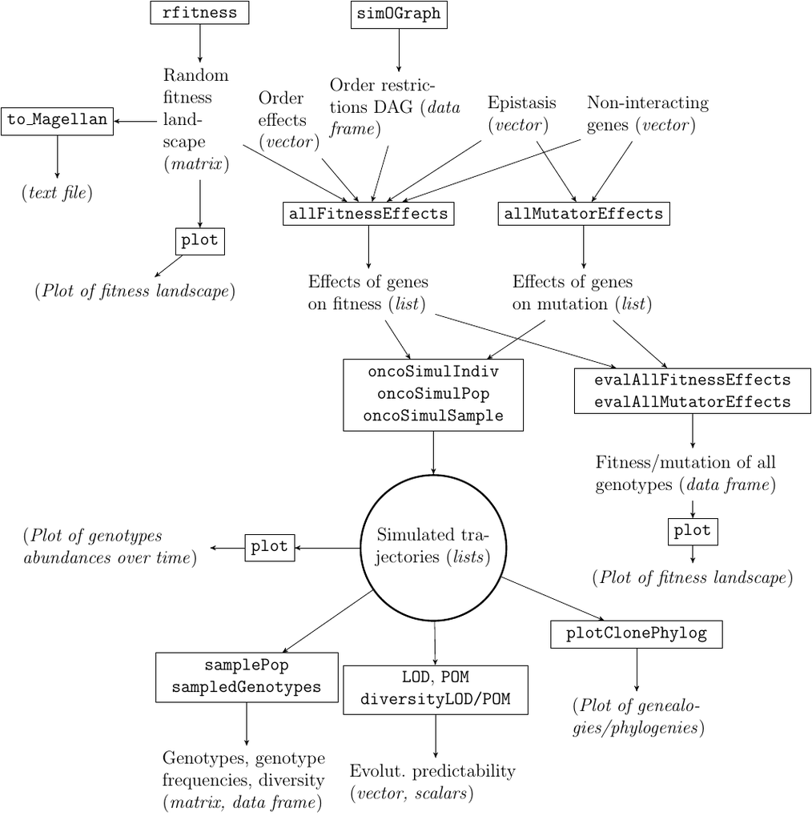

Figure 1.1: Relationships between the main functions in OncoSimulR.

## 1.3 Examples of questions that can be addressed with OncoSimulR

Most of the examples in the rest of this vignette, starting with those in 1.6, focus on the mechanics. Here, we will illustrate some problems in cancer genomics and evolutionary genetics where OncoSimulR could be of help. This section does not try to provide an answer to any of these questions (those would be full papers by themselves). Instead, this section simply tries to illustrate some kinds of questions where you can use OncoSimulR; of course, the possible uses of OncoSimulR are only limited by your ingenuity. Here, I will only use short snippets of working code as we are limited by time of execution; for real work you would want to use many more scenarios and many more simulations, you would use appropriate statistical methods to compare the output of runs, etc, etc, etc.

```r
## Load the package
library(OncoSimulR)
```

### 1.3.1 Recovering restrictions in the order of accumulation of mutations

This is a question that was addressed, for instance, in Diaz-Uriarte (2015): do methods that try to infer restrictions in the order of accumulation of mutations (e.g., Szabo and Boucher 2008; Gerstung et al. 2009; Ramazzotti et al. 2015) work well under different evolutionary models and with different sampling schemes?

A possible way to examine that question would involve:

- generating random DAGs that encode restrictions;
- simulating cancer evolution using those DAGs;
- sampling the data and adding different levels of noise to the sampled data;
- running the inferential method;
- comparing the inferred DAG with the original, true, one.

```r
## For reproducibility
set.seed(2)
RNGkind("L'Ecuyer-CMRG")

## Simulate a DAG
g1 <- simOGraph(4, out = "rT")

## Simulate 10 evolutionary trajectories
s1 <- oncoSimulPop(10, allFitnessEffects(g1, drvNames = 1:4),
                   mc.cores = 2, ## adapt to your hardware
                   seed = NULL) ## for reproducibility of vignette
## You are running Windows. Setting mc.cores = 1

## Sample those data uniformly, and add noise
d1 <- samplePop(s1, timeSample = "unif", propError = 0.1)
##
##  Subjects by Genes matrix of 10 subjects and 4 genes.

## You would now run the appropriate inferential method and
## compare observed and true. For example

## require(Oncotree)
## fit1 <- oncotree.fit(d1)

## Now, you'd compare fitted and original. This is well beyond
## the scope of this document (and OncoSimulR itself).
```

### 1.3.2 Sign epistasis and probability of crossing fitness valleys

This question, and the question in the next section (1.3.3), encompass a wide range of issues that have been addressed in evolutionary genetics studies and which include from detailed analysis of simple models with a few uphill paths and valleys as in Weissman et al. (2009) or Ochs and Desai (2015), to questions that refer to larger, more complex fitness landscapes as in Szendro, Franke, et al. (2013) or Franke et al. (2011) (see below).

Using as an example Ochs and Desai (2015) (we will see this example again in section 5.3, where we cover different ways of specifying fitness), we could specify the fitness landscape and run simulations until fixation (with argument `fixation` to `oncoSimulPop` —see more details in section 6.3.3 and 6.3.4, again with this example). We would then examine the proportion of genotypes fixed under different scenarios. And we can extend this example by adding mutator genes:

```r
## For reproducibility
set.seed(2)
RNGkind("L'Ecuyer-CMRG")

## Specify fitness effects.

## Numeric values arbitrary, but set the intermediate genotype en
## route to ui as mildly deleterious so there is a valley.

## As in Ochs and Desai, the ui and uv genotypes
## can never appear.

u <- 0.2; i <- -0.02; vi <- 0.6; ui <- uv <- -Inf

od <- allFitnessEffects(
    epistasis = c("u" = u,  "u:i" = ui,
                  "u:v" = uv, "i" = i,
                  "v:-i" = -Inf, "v:i" = vi))

## For the sake of extending this example, also turn i into a
## mutator gene

odm <- allMutatorEffects(noIntGenes = c("i" = 50))

## How do mutation and fitness look like for each genotype?
evalAllGenotypesFitAndMut(od, odm, addwt = TRUE)
##   Genotype Fitness MutatorFactor
## 1       WT   1.000             1
## 2        i   0.980            50
## 3        u   1.200             1
## 4        v   0.000             1
## 5     i, u   0.000            50
## 6     i, v   1.568            50
## 7     u, v   0.000             1
## 8  i, u, v   0.000            50
```

Ochs and Desai explicitly say “Each simulated population was evolved until either the uphill genotype or valley-crossing genotype fixed.” So we will use `fixation`.

```r
## Set a small initSize, as o.w. unlikely to pass the valley
initS <- 10
## The number of replicates is tiny, for the sake of speed
## of creation of the vignette. Even fewer in Windows, since we run on a single
## core

if(.Platform$OS.type == "windows") {
    nruns <- 4
} else {
    nruns <- 10
}

od_sim <- oncoSimulPop(nruns, od, muEF = odm,
                       fixation = c("u", "i, v"), initSize = initS,
                       model = "McFL",
                       mu = 1e-4, detectionDrivers = NA,
                       finalTime = NA,
                       detectionSize = NA, detectionProb = NA,
                       onlyCancer = TRUE,
                       mc.cores = 2, ## adapt to your hardware
                       seed = NULL) ## for reproducibility
## You are running Windows. Setting mc.cores = 1
## What is the frequency of each final genotype?
sampledGenotypes(samplePop(od_sim))
##
##  Subjects by Genes matrix of 4 subjects and 3 genes.
##   Genotype Freq
## 1     i, v    1
## 2        u    3
##
##  Shannon's diversity (entropy) of sampled genotypes: 0.5623351
```

### 1.3.3 Predictability of evolution in complex fitness landscapes

Focusing now on predictability in more general fitness landscapes, we would run simulations under random fitness landscapes with varied ruggedness, and would then examine the evolutionary predictability of the trajectories with measures such as “Lines of Descent” and “Path of the Maximum” (Szendro, Franke, et al. 2013) and the diversity of the sampled genotypes under different sampling regimes (see details in section 13).

```r
## For reproducibility
set.seed(7)
RNGkind("L'Ecuyer-CMRG")


## Repeat the following loop for different combinations of whatever
## interests you, such as number of genes, or distribution of the
## c and sd (which affect how rugged the landscape is), or
## reference genotype, or evolutionary model, or stopping criterion,
## or sampling procedure, or ...

##  Generate a random fitness landscape, from the Rough Mount
##  Fuji model, with g genes, and c ("slope" constant) and
##  reference chosen randomly (reference is random by default and
##  thus not specified below). Require a minimal number of
##  accessible genotypes

g <- 6
c <- runif(1, 1/5, 5)
rl <- rfitness(g, c = c, min_accessible_genotypes = g)

## Plot it if you want; commented here as it takes long for a
## vignette

## plot(rl)

## Obtain landscape measures from MAGELLAN. Export to MAGELLAN and
## call your own copy of MAGELLAN's binary

## to_Magellan(rl, file = "rl1.txt") ## (Commented out here to avoid writing files)

## or use the binary copy provided with OncoSimulR
## see also below.

Magellan_stats(rl) ## (Commented out here to avoid writing files)
##      ngeno     npeaks     nsinks      gamma     gamma.        r.s
##     64.000      2.000      1.000      0.769      0.854      0.372
##    nchains     nsteps       nori      depth       magn       sign
##      1.000      5.000      4.000      2.000      0.863      0.129
##      rsign       f.1.       X.2.      f.3..     mode_f     outD_m
##      0.008      0.916      0.010      0.074      1.000      0.346
##     outD_v    steps_m    reach_m     fitG_m      opt_i mProbOpt_0
##      1.587      3.052     13.597     32.452     60.000      0.128
##    opt_i.1 mProbOpt_1
##     63.000      0.872

## Simulate evolution in that landscape many times (here just 10)
simulrl <- oncoSimulPop(10, allFitnessEffects(genotFitness = rl),
                        keepPhylog = TRUE, keepEvery = 1,
                        initSize = 4000,
                        seed = NULL, ## for reproducibility
                        mc.cores = 2) ## adapt to your hardware
## You are running Windows. Setting mc.cores = 1

## Obtain measures of evolutionary predictability
diversityLOD(LOD(simulrl))
## [1] 2.163956
diversityPOM(POM(simulrl))
## [1] 2.163956
sampledGenotypes(samplePop(simulrl, typeSample = "whole"))
##
##  Subjects by Genes matrix of 10 subjects and 6 genes.
##   Genotype Freq
## 1        A    1
## 2     A, C    1
## 3     A, D    1
## 4        B    1
## 5     B, D    1
## 6     C, D    1
## 7     C, F    1
## 8        E    1
## 9        F    2
##
##  Shannon's diversity (entropy) of sampled genotypes: 2.163956
```

### 1.3.4 Mutator and antimutator genes

The effects of mutator and antimutator genes have been examined both in cancer genetics (Nowak 2006; Tomlinson, Novelli, and Bodmer 1996) and in evolutionary genetics (Gerrish et al. 2007), and are related to wider issues such as Muller’s ratchet and the evolution of sex. There are, thus, a large range of questions related to mutator and antimutator genes.

One question addressed in Tomlinson, Novelli, and Bodmer (1996) concerns under what circumstances mutator genes are likely to play a role in cancer progression. For instance, Tomlinson, Novelli, and Bodmer (1996) find that an increased mutation rate is more likely to matter if the number of required mutations in driver genes needed to reach cancer is large and if the mutator effect is large.

We might want to ask, then, how long it takes before to reach cancer under different scenarios. Time to reach cancer is stored in the component `FinalTime` of the output. We would specify different numbers and effects of mutator genes (argument `muEF`). We would also change the criteria for reaching cancer and in our case we can easily do that by specifying different numbers in `detectionDrivers`. Of course, we would also want to examine the effects of varying numbers of mutators, drivers, and possibly fitness consequences of mutators. Below we assume mutators are neutral and we assume there are no additional genes with deleterious mutations, but this need not be so, of course (see also Tomlinson, Novelli, and Bodmer 1996; Gerrish et al. 2007; Christopher McFarland, Mirny, and Korolev 2014).

Let us run an example. For the sake of simplicity, we assume no epistatic interactions.

```r
sd <- 0.1 ## fitness effect of drivers
sm <- 0 ## fitness effect of mutator
nd <- 20 ## number of drivers
nm <- 5  ## number of mutators
mut <- 10 ## mutator effect

fitnessGenesVector <- c(rep(sd, nd), rep(sm, nm))
names(fitnessGenesVector) <- 1:(nd + nm)
mutatorGenesVector <- rep(mut, nm)
names(mutatorGenesVector) <- (nd + 1):(nd + nm)

ft <- allFitnessEffects(noIntGenes = fitnessGenesVector,
                        drvNames = 1:nd)
mt <- allMutatorEffects(noIntGenes = mutatorGenesVector)
```

Now, simulate using the fitness and mutator specification. We fix the number of drivers to cancer, and we stop when those numbers of drivers are reached. Since we only care about the time it takes to reach cancer, not the actual trajectories, we set `keepEvery = NA`:

```r
## For reproducibility
set.seed(2)
RNGkind("L'Ecuyer-CMRG")


ddr <- 4
st <- oncoSimulPop(4, ft, muEF = mt,
                   detectionDrivers = ddr,
                   finalTime = NA,
                   detectionSize = NA,
                   detectionProb = NA,
                   onlyCancer = TRUE,
                   keepEvery = NA,
                   mc.cores = 2, ## adapt to your hardware
                   seed = NULL) ## for reproducibility
## You are running Windows. Setting mc.cores = 1

## How long did it take to reach cancer?
unlist(lapply(st, function(x) x$FinalTime))
## [1] 545 240 190 392
```

(Incidentally, notice that it is easy to get OncoSimulR to throw an exception if you accidentally specify a huge mutation rate when all mutator genes are mutated: see section 15.7.)

### 1.3.5 Epistatic interactions between drivers and passengers in cancer and the consequences of order effects

#### 1.3.5.1 Epistatic interactions between drivers and passengers

Bauer, Siebert, and Traulsen (2014) have examined the effects of epistatic relationships between drivers and passengers in cancer initiation. We could use their model as a starting point, and examine how likely cancer is to develop under different variations of their model and different evolutionary scenarios (e.g., initial sample size, mutation rates, evolutionary model, etc).

There are several ways to specify their model, as we discuss in section 5.1. We will use one based on DAGs here:

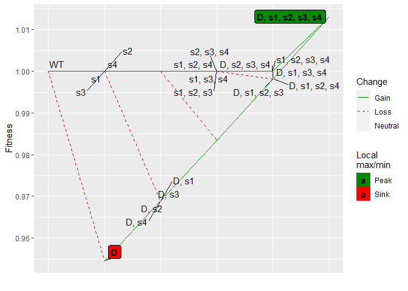

```r
K <- 4
sp <- 1e-5
sdp <- 0.015
sdplus <- 0.05
sdminus <- 0.1

cnt <- (1 + sdplus)/(1 + sdminus)
prod_cnt <- cnt - 1
bauer <- data.frame(parent = c("Root", rep("D", K)),
                    child = c("D", paste0("s", 1:K)),
                    s = c(prod_cnt, rep(sdp, K)),
                    sh = c(0, rep(sp, K)),
                    typeDep = "MN")
fbauer <- allFitnessEffects(bauer)
(b1 <- evalAllGenotypes(fbauer, order = FALSE, addwt = TRUE))
##             Genotype   Fitness
## 1                 WT 1.0000000
## 2                  D 0.9545455
## 3                 s1 1.0000100
## 4                 s2 1.0000100
## 5                 s3 1.0000100
## 6                 s4 1.0000100
## 7              D, s1 0.9688636
## 8              D, s2 0.9688636
## 9              D, s3 0.9688636
## 10             D, s4 0.9688636
## 11            s1, s2 1.0000200
## 12            s1, s3 1.0000200
## 13            s1, s4 1.0000200
## 14            s2, s3 1.0000200
## 15            s2, s4 1.0000200
## 16            s3, s4 1.0000200
## 17         D, s1, s2 0.9833966
## 18         D, s1, s3 0.9833966
## 19         D, s1, s4 0.9833966
## 20         D, s2, s3 0.9833966
## 21         D, s2, s4 0.9833966
## 22         D, s3, s4 0.9833966
## 23        s1, s2, s3 1.0000300
## 24        s1, s2, s4 1.0000300
## 25        s1, s3, s4 1.0000300
## 26        s2, s3, s4 1.0000300
## 27     D, s1, s2, s3 0.9981475
## 28     D, s1, s2, s4 0.9981475
## 29     D, s1, s3, s4 0.9981475
## 30     D, s2, s3, s4 0.9981475
## 31    s1, s2, s3, s4 1.0000400
## 32 D, s1, s2, s3, s4 1.0131198

## How does the fitness landscape look like?
plot(b1, use_ggrepel = TRUE) ## avoid overlapping labels
## Warning: ggrepel: 12 unlabeled data points (too many overlaps).
## Consider increasing max.overlaps
```

Now run simulations and examine how frequently the runs end up with population sizes larger than a pre-specified threshold; for instance, below we look at increasing population size 4x in the default maximum number of 2281 time periods (for real, you would of course increase the number of total populations, the range of initial population sizes, model, mutation rate, required population size or number of drivers, etc):

```r
## For reproducibility
set.seed(2)
RNGkind("L'Ecuyer-CMRG")

totalpops <- 5
initSize <- 100
sb1 <- oncoSimulPop(totalpops, fbauer, model = "Exp",
                    initSize = initSize,
                    onlyCancer = FALSE,
                    mc.cores = 2, ## adapt to your hardware
                    seed = NULL) ## for reproducibility
## You are running Windows. Setting mc.cores = 1

## What proportion of the simulations reach 4x initSize?
sum(summary(sb1)[, "TotalPopSize"] > (4 * initSize))/totalpops
## [1] 0
```

Alternatively, to examine how long it takes to reach cancer for a pre-specified size, you could look at the value of `FinalTime` as we did above (section 1.3.4) after running simulations with `onlyCancer = TRUE` and `detectionSize` set to some reasonable value:

```r
totalpops <- 5
initSize <- 100
sb2 <- oncoSimulPop(totalpops, fbauer, model = "Exp",
                    initSize = initSize,
                    onlyCancer = TRUE,
                    detectionSize = 10 * initSize,
                    mc.cores = 2, ## adapt to your hardware
                    seed = NULL) ## for reproducibility
## You are running Windows. Setting mc.cores = 1

## How long did it take to reach cancer?
unlist(lapply(sb2, function(x) x$FinalTime))
## [1]  147  162  546  400 1086
```

#### 1.3.5.2 Consequences of order effects for cancer initiation

Instead of focusing on different models for epistatic interactions, you might want to examine the consequences of order effects (Ortmann et al. 2015). You would proceed as above, but using models that differ by, say, the presence or absence of order effects. Details on their specification are provided in section 3.6. Here is one particular model (you would, of course, want to compare this to models without order effects or with other magnitudes and types of order effects):

```r
## Order effects involving three genes.

## Genotype "D, M" has different fitness effects
## depending on whether M or D mutated first.
## Ditto for genotype "F, D, M".

## Meaning of specification: X > Y means
## that X is mutated before Y.


o3 <- allFitnessEffects(orderEffects = c(
                            "F > D > M" = -0.3,
                            "D > F > M" = 0.4,
                            "D > M > F" = 0.2,
                            "D > M"     = 0.1,
                            "M > D"     = 0.5))

## With the above specification, let's double check
## the fitness of the possible genotypes

(oeag <- evalAllGenotypes(o3, addwt = TRUE, order = TRUE))
##     Genotype Fitness
## 1         WT    1.00
## 2          D    1.00
## 3          F    1.00
## 4          M    1.00
## 5      D > F    1.00
## 6      D > M    1.10
## 7      F > D    1.00
## 8      F > M    1.00
## 9      M > D    1.50
## 10     M > F    1.00
## 11 D > F > M    1.54
## 12 D > M > F    1.32
## 13 F > D > M    0.77
## 14 F > M > D    1.50
## 15 M > D > F    1.50
## 16 M > F > D    1.50
```

Now, run simulations and examine how frequently the runs do not end up in extinction. As above, for real, you would of course increase the number of total populations, the range of initial population sizes, mutation rate, etc:

```r
## For reproducibility
set.seed(2)
RNGkind("L'Ecuyer-CMRG")

totalpops <- 5
soe1 <- oncoSimulPop(totalpops, o3, model = "Exp",
                    initSize = 500,
                    onlyCancer = FALSE,
                    mc.cores = 2, ## adapt to your hardware
                    seed = NULL) ## for reproducibility
## You are running Windows. Setting mc.cores = 1

## What proportion of the simulations do not end up extinct?
sum(summary(soe1)[, "TotalPopSize"] > 0)/totalpops
## [1] 0
```

As we just said, alternatively, to examine how long it takes to reach cancer you could run simulations with `onlyCancer = TRUE` and look at the value of `FinalTime` as we did above (section 1.3.4).

### 1.3.6 Simulating evolution with frequency-dependent fitness

The new frequency-dependent fitness funcionality allows users to run simulations in a different way, defining fitness (birth rates) as functions of clone’s frequencies. We can thus model frequency-dependent selection, as well as predation and parasitism, cooperation and mutualism, and commensalism. See section 10 for further details and examples.

## 1.4 Trade-offs and what is OncoSimulR not well suited for

OncoSimulR is designed for complex fitness specifications and selection scenarios and uses forward-time simulations; the types of questions where OncoSimulR can be of help are discussed in sections 1.2 and 1.3 and running time and space consumption of OncoSimulR are addressed in section 2. You should be aware that **coalescent simulations**, sometimes also called backward-time simulations, are much more efficient for simulating neutral data as well as some special selection scenarios (Yuan et al. 2012; Carvajal-Rodriguez 2010; Hoban, Bertorelle, and Gaggiotti 2011).

In addition, since OncoSimulR allows you to specify fitness with arbitrary epistatic and order effects, as well as mutator effects, you need to learn the syntax of how to specify those effects and you might be paying a performance penalty if your scenario does not require this complexity. For instance, in the model of Beerenwinkel et al. (2007), the fitness of a genotype depends only on the total number of drivers mutated, but not on which drivers are mutated (and, thus, not on the epistatic interactions nor the order of accumulation of the drivers). This means that the syntax for specifying that model could probably be a lot simpler (e.g., specify $s$ per driver).

But it also means that code written for just that case could probably run much faster. First, because fitness evaluation is easier. Second, and possibly much more important, because what we need to keep track of leads to much simpler and economic structures: we do not need to keep track of clones (where two cells are regarded as different clones if they differ anywhere in their genotype), but only of clone types or clone classes as defined by the number of mutated drivers, and keeping track of clones can be expensive —see sections 2 and 15.2.

So for those cases where you do not need the full flexibility of OncoSimulR, special purpose software might be easier to use and faster to run. Of course, for some types of problems this special purpose software might not be available, though.

## 1.5 Steps for using OncoSimulR

Using this package will often involve the following steps:

1. Specify fitness effects: sections 3 and 5.
2. Simulate cancer progression: section 6. You can simulate for a single individual or subject or for a set of subjects. You will need to:
   - Decide on a model. This basically amounts to choosing a model with exponential growth (“Exp” or “Bozic”) or a model with carrying capacity (“McFL”). If exponential growth, you can choose whether the the effects of mutations operate on the death rate (“Bozic”) or the birth rate (“Exp”)[^1].
   - Specify other parameters of the simulation. In particular, decide when to stop the simulation, mutation rates, etc.

   Of course, at least for initial playing around, you can use the defaults.
3. Sample from the simulated data and do something with those simulated data (e.g., fit an OT model to them, examine diversity or time until cancer, etc). Most of what you do with the data, however, is outside the scope of this package and this vignette.

Before anything else, let us load the package in case it was not yet loaded. We also explicitly load *graph* and *igraph* for the vignette to work (you do not need that for your usual interactive work). And I set the default color for vertices in igraph.

```r
library(OncoSimulR)
library(graph)
library(igraph)
igraph_options(vertex.color = "SkyBlue2")
```

To be explicit, what version are we running?

```r
packageVersion("OncoSimulR")
## [1] '2.99.7'
```

## 1.6 Two quick examples of fitness specifications

Following 1.5 we will run two very minimal examples. First a model with a few genes and **epistasis**:

```r
## 1. Fitness effects: here we specify an
##    epistatic model with modules.
sa <- 0.1
sb <- -0.2
sab <- 0.25
sac <- -0.1
sbc <- 0.25
sv2 <- allFitnessEffects(epistasis = c("-A : B" = sb,
                                       "A : -B" = sa,
                                       "A : C" = sac,
                                       "A:B" = sab,
                                       "-A:B:C" = sbc),
                         geneToModule = c(
                             "A" = "a1, a2",
                             "B" = "b",
                             "C" = "c"),
                         drvNames = c("a1", "a2", "b", "c"))
evalAllGenotypes(sv2, addwt = TRUE)
##        Genotype Fitness
## 1            WT   1.000
## 2            a1   1.100
## 3            a2   1.100
## 4             b   0.800
## 5             c   1.000
## 6        a1, a2   1.100
## 7         a1, b   1.250
## 8         a1, c   0.990
## 9         a2, b   1.250
## 10        a2, c   0.990
## 11         b, c   1.000
## 12    a1, a2, b   1.250
## 13    a1, a2, c   0.990
## 14     a1, b, c   1.125
## 15     a2, b, c   1.125
## 16 a1, a2, b, c   1.125

## 2. Simulate the data. Here we use the "McFL" model and set
##    explicitly parameters for mutation rate, initial size, size
##    of the population that will end the simulations, etc

RNGkind("Mersenne-Twister")
set.seed(983)
ep1 <- oncoSimulIndiv(sv2, model = "McFL",
                      mu = 5e-6,
                      sampleEvery = 0.025,
                      keepEvery = 0.5,
                      initSize = 2000,
                      finalTime = 3000,
                      onlyCancer = FALSE)
```

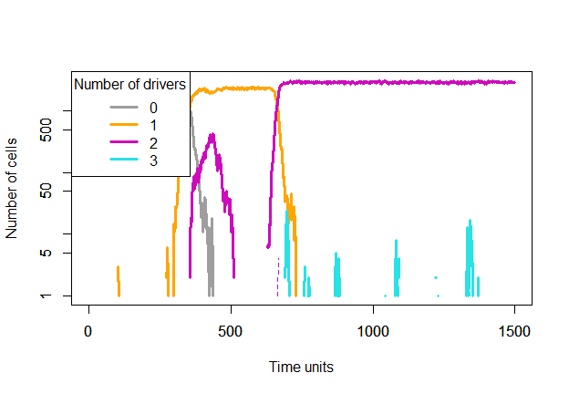

Figure 1.2: Plot of drivers of an epistasis simulation.

```r
## 3. We will not analyze those data any further. We will only plot
## them.  For the sake of a small plot, we thin the data.
plot(ep1, show = "drivers", xlim = c(0, 1500),
     thinData = TRUE, thinData.keep = 0.5)
```

As a second example, we will use a model where we specify **restrictions in the order of accumulation of mutations using a DAG** with the pancreatic cancer poset in Gerstung et al. (2011) (see more details in section 5.5):

```r
## 1. Fitness effects:
pancr <- allFitnessEffects(
    data.frame(parent = c("Root", rep("KRAS", 4),
                   "SMAD4", "CDNK2A",
                   "TP53", "TP53", "MLL3"),
               child = c("KRAS","SMAD4", "CDNK2A",
                   "TP53", "MLL3",
                   rep("PXDN", 3), rep("TGFBR2", 2)),
               s = 0.1,
               sh = -0.9,
               typeDep = "MN"),
    drvNames = c("KRAS", "SMAD4", "CDNK2A", "TP53",
                 "MLL3", "TGFBR2", "PXDN"))
```

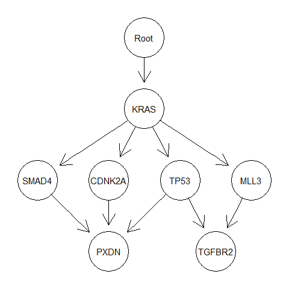

Figure 1.3: Plot of DAG corresponding to fitnessEffects object.

```r
## Plot the DAG of the fitnessEffects object
plot(pancr)
```

```r
## 2. Simulate from it. We change several possible options.

set.seed(1) ## Fix the seed, so we can repeat it
## We set a small finalTime to speed up the vignette
ep2 <- oncoSimulIndiv(pancr, model = "McFL",
                     mu = 1e-6,
                     sampleEvery = 0.02,
                     keepEvery = 1,
                     initSize = 1000,
                     finalTime = 20000,
                     detectionDrivers = 3,
                     onlyCancer = FALSE)
```

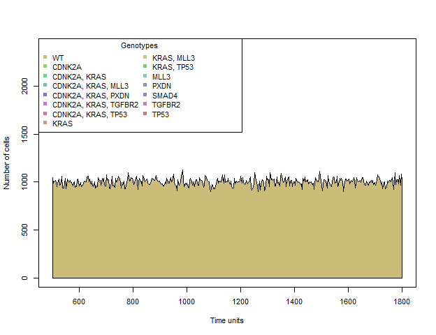

Figure 1.4: Plot of genotypes of a simulation from a DAG.

```r
## 3. What genotypes and drivers we get? And play with limits
##    to show only parts of the data. We also aggressively thin
##    the data.
par(cex = 0.7)
plot(ep2, show = "genotypes", xlim = c(500, 1800),
     ylim = c(0, 2400),
     thinData = TRUE, thinData.keep = 0.3)
```

The rest of this vignette explores all of those functions and arguments in much more detail.

## 1.7 Citing OncoSimulR and other documentation

In R, you can do

```r
citation("OncoSimulR")
##
## If you use OncoSimulR, please cite the OncoSimulR
## Bioinformatics paper.  OncoSimulR has been used in three
## large comparative studies of methods to infer restrictions
## in the order of accumulation of mutations (cancer
## progression models) published in PLoS Computational Biology,
## Bioinformatics and BMC Bioinformatics; you might want to
## cite those too, if appropriate, such as when referring to
## using evolutionary simulations to assess oncogenetic
## tree/cancer progression methods performance.
##
##   R Diaz-Uriarte. OncoSimulR: genetic simulation with
##   arbitrary epistasis and mutator genes in asexual
##   populations.  2017. Bioinformatics, 33, 1898--1899.
##   https://doi.org/10.1093/bioinformatics/btx077.
##
##   R Diaz-Uriarte and C. Vasallo. Every which way? On
##   predicting tumor evolution using cancer progression models
##   2019 PLoS Computational Biology
##   https://journals.plos.org/ploscompbiol/article?id=10.1371/journal.pcbi.1007246
##
##   R Diaz-Uriarte. Cancer progression models and fitness
##   landscapes: a many-to-many relationship 2017
##   Bioinformatics.
##   https://academic.oup.com/bioinformatics/advance-article/doi/10.1093/bioinformatics/btx663/
##
##   R Diaz-Uriarte. Identifying restrictions in the order of
##   accumulation of mutations during tumor progression:
##   effects of passengers, evolutionary models, and sampling
##   2015. BMC Bioinformatics, 16(41).
##
## To see these entries in BibTeX format, use
## 'print(<citation>, bibtex=TRUE)', 'toBibtex(.)', or set
## 'options(citation.bibtex.max=999)'.
```

which will tell you how to cite the package. Please, do cite the Bionformatics paper if you use the package in publications.

This is the URL for the Bioinformatics paper: https://doi.org/10.1093/bioinformatics/btx077 (there is also an early preprint at [bioRxiv](http://biorxiv.org/content/early/2016/08/14/069500), but it should now point to the Bioinformatics paper).

### 1.7.1 HTML and PDF versions of the vignette

A PDF version of this vignette is available from https://rdiaz02.github.io/OncoSimul/pdfs/OncoSimulR.pdf. And an HTML version from https://rdiaz02.github.io/OncoSimul/OncoSimulR.html. These files should correspond to the most recent, GitHub version, of the package (i.e., they might include changes not yet available from the BioConductor package). Beware that the PDF might have figures and R code that do not fit on the page, etc.

## 1.8 Testing, code coverage, and other examples

OncoSimulR includes more than 2000 tests that are run at every check cycle. These tests provide a code coverage of more than 90% including both the C++ and R code. Another set of over 500 long-running (several hours) tests can be run on demand (see directory ‘/tests/manual’). In addition to serving as test cases, some of that code also provides further examples of usage.

## 1.9 Versions

In this vignette and the documentation I often refer to version 1 (v.1) and version 2 of OncoSimulR. Version 1 is the version available up to, and including, BioConductor v. 3.1. Version 2 of OncoSimulR is available starting from BioConductor 3.2 (and, of course, available too from development versions of BioC). So, if you are using the current stable or development version of BioConductor, or you grab the sources from GitHub (https://github.com/rdiaz02/OncoSimul) you are using what we call version 2. **The functionality of version has been removed.**

# 2 Running time and space consumption of OncoSimulR

Time to complete the simulations and size of returned objects (space consumption) depend on several, interacting factors. The usual rule of “experiment before launching a large number of simulations” applies, but here we will walk through several cases to get a feeling for the major factors that affect speed and size. Many of the comments on this section need to use ideas discussed in other places of this document; if you read this section first, you might want to come back after reading the relevant parts.

Speed will depend on:

- Your hardware, of course.
- The evolutionary model.
- The granularity of how often you keep data (`keepEvery` argument). Note that the default, which is to keep as often as you sample (so that we preserve all history) can lead to slow execution times.
- The mutation rate, because higher mutation rates lead to more clones, and more clones means we need to iterate over, well, more clones, and keep larger data structures.
- The fitness specification: more complex fitness specifications tend to be slightly slower but specially different fitness specifications can have radically different effects on the evolutionary trajectories, accessibility of fast growing genotypes and, generally, the evolutionary dynamics.
- The stopping conditions (`detectionProb`, `detectionDrivers`, `detectionSize` arguments) and whether or not simulations are run until cancer is reached (`onlyCancer` argument).
- Most of the above factors can interact in complex ways.

Size of returned objects will depend on:

- Any factor that affects the number of clones tracked/returned, in particular: initial sizes and stopping conditions, mutation rate, and how often you keep data (the `keepEvery` argument can make a huge difference here).
- Whether or not you keep the complete genealogy of clones (this affects slightly the size of returned object, not speed).

In the sections that follow, we go over several cases to understand some of the main settings that affect running time (or execution time) and space consumption (the size of returned objects). It should be understood, however, that many of the examples shown below do not represent typical use cases of OncoSimulR and are used only to identify what and how affects running time and space consumption. As we will see in most examples in this vignette, typical use cases of OncoSimulR involve hundreds to thousands of genes on population sizes up to $10^5$ to $10^7$.

Note that most of the code in this section is not executed during the building of the vignette to keep vignette build time reasonable and prevent using huge amounts of RAM. All of the code, ready to be sourced and run, is available from the ‘inst/miscell’ directory (and the summary output from some of the benchmarks is available from the ‘miscell-files/vignette_bench_Rout’ directory of the main OncoSimul repository at https://github.com/rdiaz02/OncoSimul).

## 2.1 Exp and McFL with “detectionProb” and pancreas example

To get familiar with some of they factors that affect time and size, we will use the fitness specification from section 1.6, with the `detectionProb` stopping mechanism (see 6.3.2). We will use the two main growth models (exponential and McFarland). Each model will be run with two settings of `keepEvery`. With `keepEvery = 1` (runs `exp1` and `mc1`), population samples are stored at time intervals of 1 (even if most of the clones in those samples later become extinct). With `keepEvery = NA` (runs `exp2` and `mc2`) no intermediate population samples are stored, so clones that become extinct at any sampling period are pruned and only the existing clones at the end of the simulation are returned (see details in 15.2.1).

Will run 100 simulations. The results I show are for a laptop with an 8-core Intel Xeon E3-1505M CPU, running Debian GNU/Linux (the results from these benchmarks are available as `data(benchmark_1)`).

```r
## Specify fitness
pancr <- allFitnessEffects(
    data.frame(parent = c("Root", rep("KRAS", 4),
                   "SMAD4", "CDNK2A",
                   "TP53", "TP53", "MLL3"),
               child = c("KRAS","SMAD4", "CDNK2A",
                   "TP53", "MLL3",
                   rep("PXDN", 3), rep("TGFBR2", 2)),
               s = 0.1,
               sh = -0.9,
               typeDep = "MN"),
    drvNames = c("KRAS", "SMAD4", "CDNK2A", "TP53",
                 "MLL3", "TGFBR2", "PXDN"))

Nindiv <- 100 ## Number of simulations run.
              ## Increase this number to decrease sampling variation

## keepEvery = 1
t_exp1 <- system.time(
    exp1 <- oncoSimulPop(Nindiv, pancr,
                            detectionProb = "default",
                            detectionSize = NA,
                            detectionDrivers = NA,
                            finalTime = NA,
                            keepEvery = 1,
                            model = "Exp",
                            mc.cores = 1))["elapsed"]/Nindiv


t_mc1 <- system.time(
    mc1 <- oncoSimulPop(Nindiv, pancr,
                           detectionProb = "default",
                           detectionSize = NA,
                           detectionDrivers = NA,
                           finalTime = NA,
                           keepEvery = 1,
                           model = "McFL",
                           mc.cores = 1))["elapsed"]/Nindiv

## keepEvery = NA
t_exp2 <- system.time(
    exp2 <- oncoSimulPop(Nindiv, pancr,
                            detectionProb = "default",
                            detectionSize = NA,
                            detectionDrivers = NA,
                            finalTime = NA,
                            keepEvery = NA,
                            model = "Exp",
                            mc.cores = 1))["elapsed"]/Nindiv


t_mc2 <- system.time(
    mc2 <- oncoSimulPop(Nindiv, pancr,
                           detectionProb = "default",
                           detectionSize = NA,
                           detectionDrivers = NA,
                           finalTime = NA,
                           keepEvery = NA,
                           model = "McFL",
                           mc.cores = 1))["elapsed"]/Nindiv
```

We can obtain times, sizes of objects, and summaries of numbers of clones, iterations, and final times doing, for instance:

```r
cat("\n\n\n t_exp1 = ", t_exp1, "\n")
object.size(exp1)/(Nindiv * 1024^2)
cat("\n\n")
summary(unlist(lapply(exp1, "[[", "NumClones")))
summary(unlist(lapply(exp1, "[[", "NumIter")))
summary(unlist(lapply(exp1, "[[", "FinalTime")))
summary(unlist(lapply(exp1, "[[", "TotalPopSize")))
```

The above runs yield the following:

Table 2.1: Benchmarks of Exp and McFL models using the default `detectionProb` with two settings of `keepEvery`.

|  | Elapsed Time, average per simulation (s) | Object Size, average per simulation (MB) | Number of Clones, median | Number of Iterations, median | Final Time, median | Total Population Size, median | Total Population Size, max. | keepEvery |
| --- | --- | --- | --- | --- | --- | --- | --- | --- |
| **exp1** | 0 | 0.04 | 2 | 254 | 252 | 1,058 | 11,046 | 1 |
| **mc1** | 0.74 | 3.9 | 12 | 816,331 | 20,406 | 696 | 979 | 1 |
| **exp2** | 0 | 0.01 | 1 | 296 | 294 | 1,021 | 21,884 | NA |
| **mc2** | 0.7 | 0.01 | 1 | 694,716 | 17,366 | 692 | 888 | NA |

The above table shows that a naive comparison (looking simply at execution time) might conclude that the McFL model is much, much slower than the Exp model. But that is not the complete story: using the `detectionProb` stopping mechanism (see 6.3.2) will lead to stopping the simulations very quickly in the exponential model because as soon as a clone with fitness $>1$ appears it starts growing exponentially. In fact, we can see that the number of iterations and the final time are much smaller in the Exp than in the McFL model. We will elaborate on this point below (section 2.2.1), when we discuss the setting for `checkSizePEvery` (here left at its default value of 20): checking the exiting condition more often (smaller `checkSizePEvery`) would probably be justified here (notice also the very large final times) and would lead to a sharp decrease in number of iterations and, thus, running time.

This table also shows that the `keepEvery = NA` setting, which was in effect in simulations `exp2` and `mc2`, can make a difference especially for the McFL models, as seen by the median number of clones and the size of the returned object. Models `exp2` and `mc2` do not store any intermediate population samples so clones that become extinct at any sampling period are pruned and only the existing clones at the end of the simulation are returned. In contrast, models `exp1` and `mc1` store population samples at time intervals of 1 (`keepEvery = 1`), even if many of those clones eventually become extinct. We will return to this issue below as execution time and object size depend strongly on the number of clones tracked.

We can run the exponential model again modifying the arguments of the `detectionProb` mechanism; in two of the models below (`exp3` and `exp4`) no detection can take place unless populations are at least 100 times larger than the initial population size, and probability of detection is 0.1 with a population size 1,000 times larger than the initial one (`PDBaseline = 5e4`, `n2 = 5e5`). In the other two models (`exp5` and `exp6`), no detection can take place unless populations are at least 1,000 times larger than the initial population size, and probability of detection is 0.1 with a population size 100,000 times larger than the initial one (`PDBaseline = 5e5`, `n2 = 5e7`)[^2]. In runs `exp3` and `exp5` we set `keepEvery = 1` and in runs `exp4` and `exp6` we set `keepEvery = NA`.

```r
t_exp3 <- system.time(
    exp3 <- oncoSimulPop(Nindiv, pancr,
                            detectionProb = c(PDBaseline = 5e4,
                                              p2 = 0.1, n2 = 5e5,
                                              checkSizePEvery = 20),
                            detectionSize = NA,
                            detectionDrivers = NA,
                            finalTime = NA,
                            keepEvery = 1,
                            model = "Exp",
                            mc.cores = 1))["elapsed"]/Nindiv

t_exp4 <- system.time(
    exp4 <- oncoSimulPop(Nindiv, pancr,
                            detectionProb = c(PDBaseline = 5e4,
                                              p2 = 0.1, n2 = 5e5,
                                              checkSizePEvery = 20),
                            detectionSize = NA,
                            detectionDrivers = NA,
                            finalTime = NA,
                            keepEvery = NA,
                            model = "Exp",
                            mc.cores = 1))["elapsed"]/Nindiv



t_exp5 <- system.time(
    exp5 <- oncoSimulPop(Nindiv, pancr,
                            detectionProb = c(PDBaseline = 5e5,
                                              p2 = 0.1, n2 = 5e7),
                            detectionSize = NA,
                            detectionDrivers = NA,
                            finalTime = NA,
                            keepEvery = 1,
                            model = "Exp",
                            mc.cores = 1))["elapsed"]/Nindiv

t_exp6 <- system.time(
    exp6 <- oncoSimulPop(Nindiv, pancr,
                            detectionProb = c(PDBaseline = 5e5,
                                              p2 = 0.1, n2 = 5e7),
                            detectionSize = NA,
                            detectionDrivers = NA,
                            finalTime = NA,
                            keepEvery = NA,
                            model = "Exp",
                            mc.cores = 1))["elapsed"]/Nindiv
```

Table 2.2: Benchmarks of Exp models modifying the default `detectionProb` with two settings of `keepEvery`.

|  | Elapsed Time, average per simulation (s) | Object Size, average per simulation (MB) | Number of Clones, median | Number of Iterations, median | Final Time, median | Total Population Size, median | Total Population Size, max. | keepEvery | PDBaseline | n2 |
| --- | --- | --- | --- | --- | --- | --- | --- | --- | --- | --- |
| **exp3** | 0.01 | 0.41 | 14 | 2,754 | 1,890 | 6,798,358 | 2.7e+08 | 1 | 50,000 | 5e+05 |
| **exp4** | 0.01 | 0.02 | 8 | 2,730 | 2,090 | 7,443,813 | 1.7e+08 | NA | 50,000 | 5e+05 |
| **exp5** | 0.84 | 0.91 | 34 | 54,333 | 2,026 | 1.4e+09 | 4.2e+10 | 1 | 5e+05 | 5e+07 |
| **exp6** | 0.54 | 0.02 | 27 | 44,288 | 2,026 | 1.2e+09 | 3.3e+10 | NA | 5e+05 | 5e+07 |

In some of the runs of `exp5` and `exp6` we get the (recoverable) exception message from the C++ code: `Recoverable exception ti set to DBL_MIN. Rerunning`, which is related to those simulations reaching total population sizes $>10^{10}$; we return to this below (section 2.4). You might also wonder why total and median population sizes are so large in these two runs, given the exiting conditions. One of the reasons is that we are using the default `checkSizePEvery = 20`, so the interval between successive checks of the exiting condition is large; this is discussed at greater length in section 2.2.1.

All the runs above used the default value `onlyCancer = TRUE`. This means that simulations will be repeated until the exiting conditions are reached (see details in section 6.3) and, therefore, any simulation that ends up in extinction will be repeated. This setting can thus have a large effect on the exponential models, because when the initial population size is not very large and we start from the wildtype, it is not uncommon for simulations to become extinct (when birth and death rates are equal and the population size is small, it is easy to reach extinction before a mutation in a gene that increases fitness occurs). But this is rarely the case in the McFarland model (unless we use really tiny initial population sizes) because of the dependency of death rate on total population size (see section 3.2.1).

The number of attempts until cancer was reached in the above models is shown in Table 2.3 (the values can be obtained from any of the above runs doing, for instance, `median(unlist(lapply(exp1, function(x) x$other$attemptsUsed)))` ):

Table 2.3: Number of attempts until cancer.

|  | Attempts until Cancer, median | Attempts until Cancer, mean | Attempts until Cancer, max. | PDBaseline | n2 |
| --- | --- | --- | --- | --- | --- |
| **exp1** | 1 | 1.9 | 7 | 600 | 1,000 |
| **mc1** | 1 | 1 | 1 | 600 | 1,000 |
| **exp2** | 2 | 2.2 | 16 | 600 | 1,000 |
| **mc2** | 1 | 1 | 1 | 600 | 1,000 |
| **exp3** | 6 | 7.7 | 40 | 50,000 | 5e+05 |
| **exp4** | 6 | 8 | 39 | 50,000 | 5e+05 |
| **exp5** | 5 | 8.3 | 41 | 5e+05 | 5e+07 |
| **exp6** | 5 | 7.2 | 30 | 5e+05 | 5e+07 |

The McFL models finish in a single attempt. The exponential model simulations where we can exit with small population sizes (`exp1`, `exp2`) need many fewer attempts to reach cancer than those where large population sizes are required (`exp3` to `exp6`). There is no relevant different among those last four, which is what we would expect: a population that has already reached a size of 50,000 cells from an initial population size of 500 is obviously a growing population where there is at least one mutant with positive fitness; thus, it unlikely to go extinct and therefore having to grow up to at least 500,000 will not significantly increase the risk of extinction.

We will now rerun all of the above models with argument `onlyCancer = FALSE`. The results are shown in Table 2.4 (note that the differences between this table and Table 2.1 for the McFL models are due only to sampling variation).

Table 2.4: Benchmarks of models in Table 2.1 and 2.2 when run with `onlyCancer = FALSE`

|  | Elapsed Time, average per simulation (s) | Object Size, average per simulation (MB) | Number of Clones, median | Number of Iterations, median | Final Time, median | Total Population Size, median | Total Population Size, mean | Total Population Size, max. | keepEvery | PDBaseline | n2 |
| --- | --- | --- | --- | --- | --- | --- | --- | --- | --- | --- | --- |
| **exp1_noc** | 0.001 | 0.041 | 1.5 | 394 | 393 | 0 | 708 | 18,188 | 1 | 600 | 1,000 |
| **mc1_noc** | 0.69 | 3.9 | 12 | 673,911 | 16,846 | 692 | 700 | 983 | 1 | 600 | 1,000 |
| **exp2_noc** | 0.001 | 0.012 | 1 | 320 | 319 | 726 | 870 | 26,023 | NA | 600 | 1,000 |
| **mc2_noc** | 0.65 | 0.014 | 1 | 628,683 | 15,716 | 694 | 704 | 910 | NA | 600 | 1,000 |
| **exp3_noc** | 0.002 | 0.15 | 2 | 718 | 694 | 0 | 2,229,519 | 5.7e+07 | 1 | 50,000 | 5e+05 |
| **exp4_noc** | 0.002 | 0.013 | 0 | 600 | 599 | 0 | 3,122,765 | 1.3e+08 | NA | 50,000 | 5e+05 |
| **exp5_noc** | 0.17 | 0.22 | 3 | 848 | 777 | 0 | 5.9e+08 | 1.5e+10 | 1 | 5e+05 | 5e+07 |
| **exp6_noc** | 0.068 | 0.013 | 0 | 784 | 716 | 0 | 4.1e+08 | 1.3e+10 | NA | 5e+05 | 5e+07 |

Now most simulations under the exponential model end up in extinction, as seen by the median population size of 0 (but not all, as the mean and max. population size are clearly away from zero). Consequently, simulations under the exponential model are now faster (and the size of the average returned object is smaller). Of course, whether one should run simulations with `onlyCancer = TRUE` or `onlyCancer = FALSE` will depend on the question being asked (see, for example, section 1.3.5 for a question where we will naturally want to use `onlyCancer = FALSE`).

To make it easier to compare results with those of the next section, Table 2.5 shows all the runs so far.

Table 2.5: Benchmarks of all models in Tables 2.1, 2.2, and 2.4.

|  | Elapsed Time, average per simulation (s) | Object Size, average per simulation (MB) | Number of Clones, median | Number of Iterations, median | Final Time, median | Total Population Size, median | Total Population Size, mean | Total Population Size, max. | keepEvery | PDBaseline | n2 | onlyCancer |
| --- | --- | --- | --- | --- | --- | --- | --- | --- | --- | --- | --- | --- |
| **exp1** | 0.001 | 0.037 | 2 | 254 | 252 | 1,058 | 1,277 | 11,046 | 1 | 600 | 1,000 | TRUE |
| **mc1** | 0.74 | 3.9 | 12 | 816,331 | 20,406 | 696 | 702 | 979 | 1 | 600 | 1,000 | TRUE |
| **exp2** | 0.001 | 0.012 | 1 | 296 | 294 | 1,021 | 1,392 | 21,884 | NA | 600 | 1,000 | TRUE |
| **mc2** | 0.7 | 0.014 | 1 | 694,716 | 17,366 | 692 | 698 | 888 | NA | 600 | 1,000 | TRUE |
| **exp3** | 0.01 | 0.41 | 14 | 2,754 | 1,890 | 6,798,358 | 1.7e+07 | 2.7e+08 | 1 | 50,000 | 5e+05 | TRUE |
| **exp4** | 0.009 | 0.016 | 8 | 2,730 | 2,090 | 7,443,813 | 1.5e+07 | 1.7e+08 | NA | 50,000 | 5e+05 | TRUE |
| **exp5** | 0.84 | 0.90 | 34 | 54,333 | 2,026 | 1.4e+09 | 3.5e+09 | 4.2e+10 | 1 | 5e+05 | 5e+07 | TRUE |
| **exp6** | 0.54 | 0.021 | 27 | 44,288 | 2,026 | 1.2e+09 | 3.2e+09 | 3.3e+10 | NA | 5e+05 | 5e+07 | TRUE |
| **exp1_noc** | 0.001 | 0.041 | 1.5 | 394 | 393 | 0 | 708 | 18,188 | 1 | 600 | 1,000 | FALSE |
| **mc1_noc** | 0.69 | 3.9 | 12 | 673,911 | 16,846 | 692 | 700 | 983 | 1 | 600 | 1,000 | FALSE |
| **exp2_noc** | 0.001 | 0.012 | 1 | 320 | 319 | 726 | 870 | 26,023 | NA | 600 | 1,000 | FALSE |
| **mc2_noc** | 0.65 | 0.014 | 1 | 628,683 | 15,716 | 694 | 704 | 910 | NA | 600 | 1,000 | FALSE |
| **exp3_noc** | 0.002 | 0.15 | 2 | 718 | 694 | 0 | 2,229,519 | 5.7e+07 | 1 | 50,000 | 5e+05 | FALSE |
| **exp4_noc** | 0.002 | 0.013 | 0 | 600 | 599 | 0 | 3,122,765 | 1.3e+08 | NA | 50,000 | 5e+05 | FALSE |
| **exp5_noc** | 0.17 | 0.22 | 3 | 848 | 777 | 0 | 5.9e+08 | 1.5e+10 | 1 | 5e+05 | 5e+07 | FALSE |
| **exp6_noc** | 0.068 | 0.013 | 0 | 784 | 716 | 0 | 4.1e+08 | 1.3e+10 | NA | 5e+05 | 5e+07 | FALSE |